# assignment1

互评作业1：数据探索性分析与预处理 一. 10G_data_new 数据集

1. 数据概览 45,000,000行数据，15个属性

```python
import os
import pandas as pd
from pathlib import Path


data_folder = Path("./10G_data_new")
parquet_files = list(data_folder.glob("part-*.parquet"))
df_list = (pd.read_parquet(file) for file in parquet_files)
data = pd.concat(df_list, ignore_index=True)
print(f"\n成功加载数据，总行数: {len(data):,}")
```

```
成功加载数据，总行数: 45,000,000
```

```python
# 显示数据概览
print("\n=== 数据概览 ===")
print(f"数据集形状: {data.shape} (行数, 列数)")
print("\n前5行数据:")
print(data.head(5))
print("\n列名和数据类型:")
print(data.dtypes)
```

```
=== 数据概览 ===
数据集形状: (45000000, 15) (行数, 列数)

前5行数据:
   id                 last_login   user_name fullname                 email  \
0   0  2024-12-02T03:49:12+00:00  RKWKCXRZFV      瞿紫玉  kuegujsk@hotmail.com
1   1  2024-08-25T05:39:16+00:00      RCLELJ      李泽宸      wslfszer@126.com
2   2  2023-12-21T14:28:09+00:00       KSHSK      詹紫玥      gputsgbf@126.com
3   3  2023-06-06T03:21:09+00:00    CCJMXPJA      姜小红  akidhwzo@outlook.com
4   4  2024-10-08T11:02:18+00:00     TJRJDNO      童泽楠       suupywzi@qq.com

   age     income gender country                          address  \
0   82  366311.83      女      美国  Non-Chinese Address Placeholder
1   71  833917.30      男      英国                     上海市淄博山水路360号
2   54  839379.17      女    澳大利亚                   北京市东莞保健中心路614号
3   18  383963.16      男      巴西                   山东省株洲配送中心路176号
4   77  337059.32      男      英国                     浙江省赤峰安康路957号

                                    purchase_history  is_active  \
0  {"avg_price":9496,"categories":"零食","items":[{...      False
1  {"avg_price":3014,"categories":"手套","items":[{...       True
2  {"avg_price":8921,"categories":"裙子","items":[{...       True
3  {"avg_price":939,"categories":"耳机","items":[{"...      False
4  {"avg_price":959,"categories":"手套","items":[{"...      False

  registration_date       phone_number  \
0        2024-10-31  +1 (804) 855-6279
1        2023-01-13    +44 1850 116429
2        2022-07-06    +61 656 440 523
3        2020-03-20  +55 54 34995-1600
4        2023-01-05    +44 5383 067377

                                       login_history
0  {"avg_session_duration":105,"devices":["deskto...
1  {"avg_session_duration":64,"devices":["mobile"...
2  {"avg_session_duration":116,"devices":["deskto...
3  {"avg_session_duration":25,"devices":["mobile"...
4  {"avg_session_duration":51,"devices":["desktop...

列名和数据类型:
id                     int64
last_login            object
user_name             object
fullname              object
email                 object
age                    int64
income               float64
gender                object
country               object
address               object
purchase_history      object
is_active               bool
registration_date     object
phone_number          object
login_history         object
dtype: object
```

2. 数据摘要

```python
import numpy as np

num_fields = list(data.select_dtypes(include=np.number).columns.values)
nom_fields = list(data.select_dtypes(exclude=np.number).columns.values)
print('标称属性:', nom_fields)
print('数值属性:', num_fields)
```

```
标称属性: ['last_login', 'user_name', 'fullname', 'email', 'gender', 'country', 'address', 'purchase_history', 'is_active', 'registration_date', 'phone_number', 'login_history']
数值属性: ['id', 'age', 'income']
```

1. 标称属性 对标称属性进行频数统计

```python
for field in nom_fields:
    print('频数统计:')
    print(data[field].value_counts())
```

```
频数统计:
last_login
2024-12-01T14:39:34+00:00    8
2024-09-23T17:06:51+00:00    8
2024-02-26T21:42:18+00:00    8
2024-07-20T11:47:38+00:00    8
2025-03-16T10:26:23+00:00    8
                            ..
2024-01-03T18:21:12+00:00    1
2023-09-01T19:39:53+00:00    1
2025-01-14T06:37:46+00:00    1
2024-01-15T07:27:45+00:00    1
2024-07-16T23:18:39+00:00    1
Name: count, Length: 33332828, dtype: int64
频数统计:
user_name
VBBMF         9
KNWHC         8
ANEES         8
ZCTDD         7
UFLTZ         7
             ..
YXIXFN        1
NCCUBHUNXR    1
KMMKHQKAYD    1
CKSORUBOUZ    1
PKDOXKCZVR    1
Name: count, Length: 42970059, dtype: int64
频数统计:
fullname
常紫薇    4864
卜紫轩    4829
卜紫欣    4812
薄紫薇    4805
路紫宁    4788
       ...
覃小红     497
萧子轩     495
银华      495
仲霞      489
```

[output cut: 96 more lines]

[output not shown]

2. 数值属性

```python
print(data.describe())
```

```
                 id           age        income
count  4.500000e+07  4.500000e+07  4.500000e+07
mean   2.250000e+07  5.899862e+01  4.999971e+05
std    1.299038e+07  2.395833e+01  2.886931e+05
min    0.000000e+00  1.800000e+01  1.000000e-02
25%    1.125000e+07  3.800000e+01  2.499804e+05
50%    2.250000e+07  5.900000e+01  4.999420e+05
75%    3.375000e+07  8.000000e+01  7.500388e+05
max    4.500000e+07  1.000000e+02  1.000000e+06
```

```python
# 缺失值统计
for field in num_fields:
    print(field+':',data[field].isnull().sum())
```

```
id: 0
age: 0
income: 0
```

3. 数据可视化
1. 标称属性

```python
%matplotlib inline
import matplotlib
import matplotlib.pyplot as plt
from matplotlib import rcParams

# 设置中文字体（Windows系统通常有SimHei）
rcParams['font.sans-serif'] = ['SimHei']  # 或者 ['Microsoft YaHei']
rcParams['axes.unicode_minus'] = False  # 解决负号显示问题

for field in nom_fields:
    fig_path = 'fig1/'+ field + '.png'

    # 创建图形
    plt.figure()

    counts = data[field].value_counts().head(10)
    ax = counts.plot.barh(figsize=(10, 6))
    # 仅显示最小值到最大值的区间（避免从0开始）
    ax.set_xlim(counts.min() * 0.9, counts.max() * 1.1)  # 留10%边距

    # 保存图形
    plt.savefig(fig_path)

    # 关闭图形，避免内存泄漏
    plt.close()
```

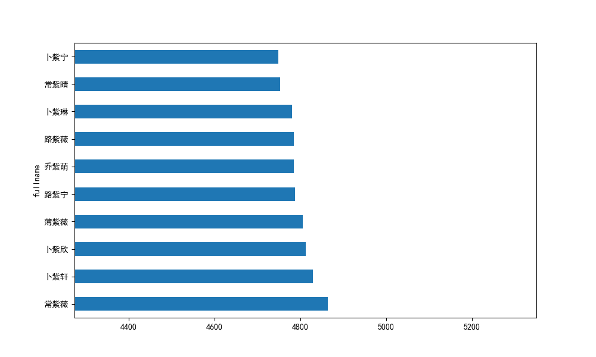

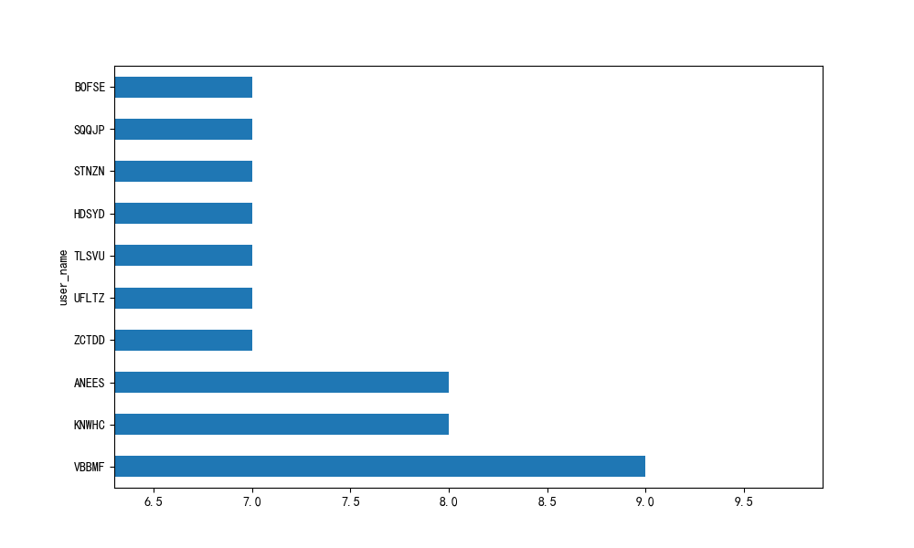

2. 数值属性

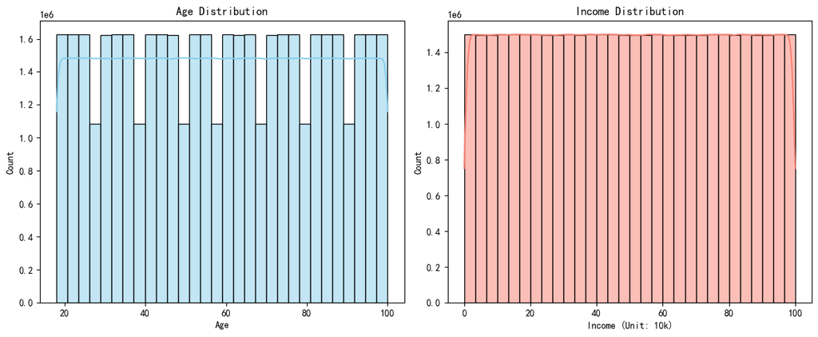

```python
import seaborn as sns
import matplotlib.pyplot as plt

plt.figure(figsize=(12, 5))

# Age分布
plt.subplot(1, 2, 1)
sns.histplot(data['age'], bins=30, kde=True, color='skyblue')
plt.title('Age Distribution')
plt.xlabel('Age')

data['income_10k'] = data['income'] / 10000
# Income分布（单位：万）
plt.subplot(1, 2, 2)
sns.histplot(data['income_10k'], bins=30, kde=True, color='salmon')
plt.title('Income Distribution')
plt.xlabel('Income (Unit: 10k)')  # 明确标注单位

plt.tight_layout()
plt.show()
```

可以看出，年龄和收入的整体分布比较均匀。 此外，还可分析二者的联合关系。分别输出散点图和六边形分箱图。

[figure not shown]

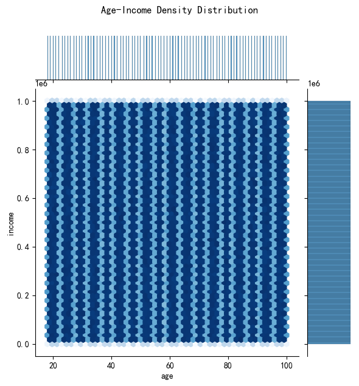

```python
plt.figure(figsize=(10, 6))
sns.scatterplot(x='age', y='income', data=data, alpha=0.6, color='teal')
plt.title('Age vs Income')
plt.ylabel('Income (Unit: 10k)')
plt.grid(True)
plt.show()

plt.figure(figsize=(10, 6))
sns.jointplot(x='age', y='income', data=data, kind='hex', cmap='Blues')
plt.suptitle('Age-Income Density Distribution', y=1.05)
plt.show()
```

从图中可以看出，年龄和收入之间并没有什么相关性，二者分布都十分均匀。

二. 30G_data_new 数据集

1. 数据概览

```python
import os
import pandas as pd
from pathlib import Path


data_folder1 = Path("./30G_data_new")
parquet_files1 = list(data_folder1.glob("part-*.parquet"))
df_list1 = (pd.read_parquet(file) for file in parquet_files1)
data1 = pd.concat(df_list1, ignore_index=True)
print(f"\n成功加载数据，总行数: {len(data1):,}")
```

```
成功加载数据，总行数: 135,000,000
```

```python
# 显示数据概览
print("\n=== 数据概览 ===")
print(f"数据集形状: {data1.shape} (行数, 列数)")
print("\n前5行数据:")
print(data1.head(5))
print("\n列名和数据类型:")
print(data1.dtypes)
```

```
=== 数据概览 ===
数据集形状: (135000000, 15) (行数, 列数)

前5行数据:
   id                 last_login   user_name fullname               email  \
0   0  2024-03-19T19:35:16+00:00  OFVIUGZMWH      覃泽川  lnsqjypb@gmail.com
1   1  2025-02-21T05:08:16+00:00      KMLBNE      吕泽越     zddfsdkt@qq.com
2   2  2024-11-26T09:33:05+00:00     NGTSMVK      卞泽楠    qxgqdrfd@163.com
3   3  2023-10-19T17:32:56+00:00      IJLZVS       卞鹏    jbjxirrf@163.com
4   4  2024-05-09T00:01:29+00:00       XCLES       郎雪     cnerwras@qq.com

   age     income gender country                          address  \
0   97    7787.23      女      日本                   西藏自治区鹤岗河滨路827号
1   31  286306.19      男      美国  Non-Chinese Address Placeholder
2   82  136343.81      男      日本                    重庆市保定检察院路503号
3   90  179801.85      男      印度                   江西省南京儿童乐园路510号
4   73  918006.25      女      英国                   福建省南宁技术学院路988号

                                    purchase_history  is_active  \
0  {"avg_price":4041,"categories":"文具","items":[{...      False
1  {"avg_price":3608,"categories":"鞋子","items":[{...      False
2  {"avg_price":6416,"categories":"文具","items":[{...      False
3  {"avg_price":8157,"categories":"办公用品","items":...       True
4  {"avg_price":1626,"categories":"户外装备","items":...      False

  registration_date       phone_number  \
0        2020-10-27   +81 37-3972-6955
1        2021-09-25  +1 (349) 601-0753
2        2023-05-15   +81 09-3007-5554
3        2020-06-29    +91 81513 74738
4        2023-08-11    +44 4509 799780

                                       login_history
0  {"avg_session_duration":14,"devices":["desktop...
1  {"avg_session_duration":46,"devices":["mobile"...
2  {"avg_session_duration":50,"devices":["mobile"...
3  {"avg_session_duration":110,"devices":["deskto...
4  {"avg_session_duration":40,"devices":["tablet"...

列名和数据类型:
id                     int64
last_login            object
user_name             object
fullname              object
email                 object
age                    int64
income               float64
gender                object
country               object
address               object
purchase_history      object
is_active               bool
registration_date     object
phone_number          object
login_history         object
dtype: object
```

2. 数据摘要

```python
import numpy as np

num_fields1 = list(data1.select_dtypes(include=np.number).columns.values)
nom_fields1 = list(data1.select_dtypes(exclude=np.number).columns.values)
print('标称属性:', nom_fields1)
print('数值属性:', num_fields1)
```

```
标称属性: ['last_login', 'user_name', 'fullname', 'email', 'gender', 'country', 'address', 'purchase_history', 'is_active', 'registration_date', 'phone_number', 'login_history']
数值属性: ['id', 'age', 'income']
```

1. 标称属性 对标称属性进行频数统计

```python
for field in nom_fields1:
    print('频数统计:')
    print(data1[field].value_counts())
```

[output not shown]

2. 数值属性

```python
print(data1.describe())
```

[output not shown]

```python
# 缺失值统计
for field in num_fields1:
    print(field+':',data1[field].isnull().sum())
```

id: 0 age: 0 income: 0

3. 数据可视化
1. 标称属性

```python
%matplotlib inline
import matplotlib
import matplotlib.pyplot as plt
from matplotlib import rcParams

# 设置中文字体（Windows系统通常有SimHei）
rcParams['font.sans-serif'] = ['SimHei']  # 或者 ['Microsoft YaHei']
rcParams['axes.unicode_minus'] = False  # 解决负号显示问题

for field in nom_fields1:
    fig_path = 'fig2/'+ field + '.png'

    # 创建图形
    plt.figure()

    counts = data1[field].value_counts().head(10)
    ax = counts.plot.barh(figsize=(10, 6))
    # 仅显示最小值到最大值的区间（避免从0开始）
    ax.set_xlim(counts.min() * 0.9, counts.max() * 1.1)  # 留10%边距

    # 保存图形
    plt.savefig(fig_path)

    # 关闭图形，避免内存泄漏
    plt.close()
```

[figure not shown]

[figure not shown]